# Project 3: Movie Review Sentiment Analysis

File Name - Project_3_1088_anikesh2

Author -

- Name - Anikesh Haran
- Email_id - anikesh2@illinois.edu
- UID - 676001088

# Part 1 - Build a Binary Classification Model

## Section 1: Technical Details

The goal of this project is to classify the sentiment of text reviews (positive or negative) using structured features extracted from a dataset. This is achieved by preprocessing the data, training a regression-based classification model (ElasticNetCV), and evaluating its performance using the Area Under the Curve (AUC) metric. I used OpenAI’s 1536-dimensional embeddings to train the classifier.

**Data Preprocessing**

The preprocess function handles the following steps:

- **Missing Value Imputation** Missing values in the feature matrices are imputed using the most frequent value strategy via SimpleImputer. This ensures the data is complete for modeling.

**Model Implementation: ElasticNetCV**

- **Overview** - ElasticNet is a regression technique that combines L1 regularization (Lasso) and L2 regularization (Ridge) to address multicollinearity and feature selection. It is particularly useful when the dataset has a mix of irrelevant and important features.
- **Hyperparameters** -
  - alpha: Controls the overall regularization strength.
  - l1_ratio: Balances the proportion of L1 and L2 regularization.
- **Scaling the Data** - ElasticNet requires standardized input features. The StandardScaler is used to scale the features to have zero mean and unit variance.
- **Training ElasticNet with Cross-Validation** - The ElasticNetCV class performs hyperparameter tuning using cross-validation. The following settings are used:
  - l1_ratio: A list of values [0.1, 0.5, 0.9, 1.0] to explore different mixes of L1 and L2 regularization.
  - alphas: A range of values [0.001, 0.01, 0.1, 1.0, 10.0] to find the optimal regularization strength.
  - cv: 10-fold cross-validation to ensure robust evaluation.

The model selected the best combination of **alpha and l1_ratio** during training the model for each split. The best alpha and l1_ratio for each split is documented below.

- **Predictions and Probabilities** ElasticNet produces continuous predictions, which are converted to probabilities using the sigmoid function (expit).
- **Model Evaluation** The model is evaluated using the Area Under the Curve (AUC) metric for all the split from 1 to 5. Here are the AUC score for each split.

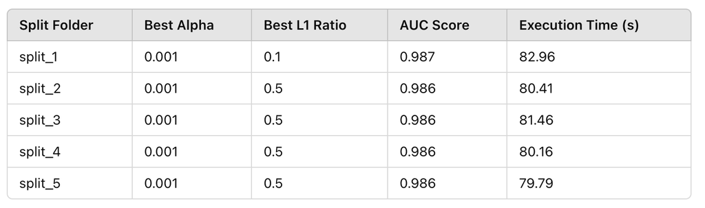

- **Model Saving** I used pickle to save the ElasticNetCV model and scaler transformation done for Part 2 - Interpretability Analysis.
- **Execution Time** Included execution time for each split in above table. On an average it took ~80s to process each split.
- **Computer System** I used Google Colab Notebook with Python3 - CPU/13 GB memory [Default Capacity] for the initial development. For final submission I used my Apple M3 Pro / Python3 / 18GB Memory.

# Part 2 - Interpretability Analysis

I did interpretability analysis on sentiment classification model trained on split1 dataset and used BERT-based sentence embeddings to interpret the results.

I tried to devide the process into a series of well-defined steps to ensure clarity and reproducibility. Below, each step is outlined with its purpose, implementation details, and relevance to interpretability.

Model binary and Embeddings of smaple positive and negative reviews are stored on GitHub at - https://github.com/harananikesh/PSL-CS598/tree/main

## Detailed Explaination of Interpretability Approach

- **Sentence Segmentation**
  - Purpose is to divide sample reviews into individual sentences, making it easier to attribute sentiment predictions to specific parts of the text
  - Implementation - The function segment_review utilizes the sent_tokenize method from the NLTK library to split a review into sentences. This enables sentence-level analysis rather than treating the entire review as a single unit.
- **Loading Pretrained Models**
  - Purpose is to use a pretrained BERT model for generating high-dimensional contextual embeddings for the sample sentences.
  - Implementation - The load_bert function initializes the bert-base-uncased tokenizer and model from the Hugging Face Transformers library. These components are essential for encoding sentences into 768-dimensional vectors that capture their contextual meaning.
- **Generating Sentence Embeddings**
  - Purpose is to convert each sentence into a fixed-length vector representation for downstream tasks such as sentiment prediction
  - Implementation - The get_sentence_embeddings function processes each sentence using the BERT tokenizer and extracts the embedding for the token, which serves as a representation of the entire sentence.
- **Dimensionality Alignment**
  - Purpose is to ensure embeddings match the required dimensionality for compatibility with downstream models (e.g., 1536 dimensions).
  - Implementation - The align_embeddings function adjusts the dimensionality using padding or PCA. Padding adds zeros if the dimension is smaller, while PCA reduces the dimensionality if it is larger.
  - Saved the final embeddings for sample reviews [sentences] into GitHub for reproducibility.
- **Sentiment Prediction**
  - Purpose is to predict the sentiment probability for each sample sentence embedding.
  - Implementation - The predict_sentence_sentiments function applies a scaler to normalize embeddings and uses a trained ElasticNet model to make predictions. The raw predictions are transformed into probabilities using the sigmoid function (expit).
- **Highlighting Key Sentences**
  - Purpose is to visually interpret which sentences contribute most to the overall sentiment of the review.
  - Implementation - The highlight_sentences function assigns a background color to sentences based on their sentiment probabilities. Sentences with high probabilities (e.g., >0.5 for positive) are highlighted in green, while sentences with low probabilities are highlighted in red.
- **Load Artifects From Github**
  - To reproduce the results, i have stored the trained model, scaler, and embeddings into GitHub repository.
  - Implementation - The load_from_github() load trained model, scaler and embeddings from Github.
- **Interpretability Analysis Workflow**
  - Integrated the aforementioned steps into a coherent pipeline for interpretability analysis.
  - Implemented function - run_interpretability_analysis_v2()

## Code to reproduce the results

```python
import os
import sys
import pickle
import nltk
nltk.download('punkt_tab')
from nltk.tokenize import sent_tokenize
import numpy as np
import torch
from sklearn.decomposition import PCA
from IPython.display import display, HTML
import random
from scipy.special import expit
import requests
import pandas as pd
from sklearn.linear_model import ElasticNetCV
from sklearn.preprocessing import StandardScaler
```

```python
#Step 1: Sentence Segmentation
def segment_review(review):
    """
    Splits a review into sentences.
    """
    return sent_tokenize(review)
```

```python
#Step 5: Predict Sentiment for Each Sentence
def predict_sentence_sentiments(mymodel, scaler, embeddings):
  """Predict sentiment probabilities for each sentence embedding."""
  # Apply the scaler transformation to embeddings
  scaled_embeddings = scaler.transform(embeddings)
  #probabilities = mymodel.predict(scaled_embeddings)[:, 1]  # Assuming positive class is at index 1
  predictions = mymodel.predict(scaled_embeddings)  # 1D array of raw predictions
  probabilities = expit(predictions)  # Sigmoid to get values between 0 and 1
  return probabilities
```

```python
#Highlight Key Sentences
def highlight_sentences(review, sentences, probabilities, threshold=0.5, prediction="positive"):
  """
  Highlight sentences contributing to the sentiment prediction.
  """
  highlighted_sentences = []
  for sentence, prob in zip(sentences, probabilities):
    highlighted = ""
    if (prediction == "positive" and prob > threshold) or (prediction == "negative" and prob < 1 - threshold):
      color = "rgba(0, 255, 0, 0.3)" if prediction == "positive" else "rgba(255, 0, 0, 0.3)"
      highlighted += f"<span style='background-color:{color}'>{sentence}</span> "
      highlighted_sentences.append(f">> {highlighted} (Probability: {prob:.3f})")
    else:
      highlighted += f"{sentence} "
      highlighted_sentences.append(f">> {highlighted} (Probability: {prob:.3f})")
  return highlighted_sentences
```

```python
#Load sentiment classification model from GitHub
def load_from_github(base_path):
  # URL of the pickle file in your public GitHub repo
  # Example: Replace with the actual URL of your file
  model_pickle_url = "https://github.com/harananikesh/PSL-CS598/raw/refs/heads/main/elasticnet_model.pkl"
  scaler_pickle_url = "https://github.com/harananikesh/PSL-CS598/raw/refs/heads/main/scaler.pkl"
  embeddings_url = "https://github.com/harananikesh/PSL-CS598/raw/refs/heads/main/embeddings_results.pkl"

  model_file_path = os.path.join(base_path, "elasticnet_model.pkl")
  scaler_file_path = os.path.join(base_path, "scaler.pkl")
  embeddings_file_path = os.path.join(base_path, "embeddings_results.pkl")

  # Step 1: Download the pickle file
  model_response = requests.get(model_pickle_url)
  if model_response.status_code == 200:
    with open(model_file_path, "wb") as f:
      f.write(model_response.content)
    print("Pickle file downloaded successfully!")
  else:
    print(f"Failed to download file: {model_response.status_code}")

  with open(model_file_path, "rb") as file:
    model = pickle.load(file)
  print("Model loaded successfully.")

  # Step 1: Download the pickle file
  scaler_response = requests.get(scaler_pickle_url)
  if scaler_response.status_code == 200:
    with open(scaler_file_path, "wb") as f:
      f.write(scaler_response.content)
    print("Scaler Pickle file downloaded successfully!")
  else:
    print(f"Failed to download file: {scaler_response.status_code}")

  with open(scaler_file_path, "rb") as file:
    scaler = pickle.load(file)
  print("Scaler loaded successfully.")

  # Download the pickle file for embeddings
  embeddings_response = requests.get(embeddings_url)
  if embeddings_response.status_code == 200:
    with open(embeddings_file_path, "wb") as f:
      f.write(embeddings_response.content)
    print("Embedding file downloaded successfully!")
  else:
    print(f"Failed to download file: {embeddings_response.status_code}")

  with open(embeddings_file_path, "rb") as file:
    embeddings = pickle.load(file)
  print("Embeddings loaded successfully.")

  return model, scaler, embeddings
```

```python
#Interpretability Analysis
def run_interpretability_analysis_v2():
  base_path = os.getcwd()

  random.seed(1088)

  print("load trained sentiment model from github")
  mymodel, myscaler, embeddings_results = load_from_github(base_path)
  embeddings_df = pd.DataFrame(embeddings_results)

  #Perform interpretability analysis for each review in the selected_reviews dataframe.
  results = []
  print("Running Interpretability Analysis for each positive and negative samples...")
  for i, row in embeddings_df.iterrows():
    review_id = row['review_id']
    review = row['review']
    sentiment = row['sentiment']
    sentiment_label = "Positive" if sentiment == 1 else "Negative"
    aligned_embeddings = row['embeddings']

    sentences = segment_review(review)
    probabilities = predict_sentence_sentiments(mymodel, myscaler, aligned_embeddings)
    interpretations = highlight_sentences(review, sentences, probabilities, threshold=0.5, prediction=sentiment_label.lower())
    results.append({
        "Review ID": review_id,
        "Sentiment": sentiment_label,
        "Highlighted Sentences": "\n".join(interpretations)
    })
  print("Completed Interpretability Analysis.")

  return results
```

```python
selected_reviews_results = run_interpretability_analysis_v2()
```

```
load trained sentiment model from github
Pickle file downloaded successfully!
Model loaded successfully.
```

```
Scaler Pickle file downloaded successfully!
Scaler loaded successfully.
Embedding file downloaded successfully!
Embeddings loaded successfully.
Running Interpretability Analysis for each positive and negative samples...
Completed Interpretability Analysis.
```

```python
from IPython.display import HTML
for result in selected_reviews_results:
  print(f"\nReview ID: {result['Review ID']}")
  print(f"Sentiment: {result['Sentiment']}")
  print("Highlighted Sentences:")
  display(HTML(result['Highlighted Sentences']))
```

```
Review ID: 2391
Sentiment: Positive
Highlighted Sentences:
```

```
Review ID: 19557
Sentiment: Positive
Highlighted Sentences:
```

>> After some further thought about this film, I find it's far too easy to dismiss this as the Boy's dream. (Probability: 0.013) >> I have actually received some spiritual strength from Northfork.......Angels do exist....we definitely are entertained by Angels....most of the time we aren't even aware of it..... At a point of spiritual and emotional turbidity in my life, I personally really needed this film. (Probability: 0.005) >> Yes, as I wrote before, it speaks to so many......can't wait to get to Heaven...  
\Being so sick of all of the FX and Formula stuff, I found this film to be genuine Cinema. (Probability: 0.042) >> All I can say is it touched me in so many ways, that I still am sorting it all out. (Probability: 0.168) >> North Fork is a wonderful film. (Probability: 0.332) >> One that brings the viewer's mind out of the gutter and into the heart. (Probability: 0.163) >> The spiritual aspect is so very intriguing to me. (Probability: 0.056) >> Pay attention, as you'll need to use the brain and heart God gave you to follow the story. (Probability: 0.035) >> I think it's possibly a bit over the heads of some, but I feel those are the individuals it speaks to most importantly. (Probability: 0.163) >> I want to view it several more times, just so I can take it all in!  
The Industry needs to study this film to realize we do exist.  
My thanks to all involved in the making of this film.\"" (Probability: 0.000)

```
Review ID: 33930
Sentiment: Positive
Highlighted Sentences:
```

>> I was deeply moved by this movie in many respects. (Probability: 0.261) >> First of all, I just want to say that Clara Lago was the most precious little thing! (Probability: 0.082) >> Such a pretty little girl. (Probability: 0.097) >> Her acting was superb as well. (Probability: 0.470) >> True to life and very human. (Probability: 0.521) >> Though I don't like the part where she had to smoke; I hope it was only a fake prop. (Probability: 0.001) >> Either way, she was absolutely wonderful and the story was so moving. (Probability: 0.027) >> I found myself immersed in the story and her character.  
It's quite interesting how I came to discover this movie actually. (Probability: 0.039) >> I was walking in blockbuster and I just happened to notice her pretty smile on the cover as I was walking by. (Probability: 0.843) >> Luckily I glanced in the downward direction that this movie was in! (Probability: 0.003) >> I thought to myself, 'Awe, look at her!' (Probability: 0.176) >> So I picked it up and saw that this movie was described as such wonderful things as \A Little Gem.\" I read the plot on the back and then thought that, well, maybe I'd look it up on IMDb first and then come back and rent it at a later time. (Probability: 0.032) >> I'm glad I didn't, because I certainly would have been missing out. (Probability: 0.005) >> After searching for a movie with my friend, I knew that I would end up regretting not renting this film, so I went back to the spot in which I originally found it and snapped it up.  
It had been on my dresser for a week, since school started for me this week and I really hadn't any time to watch it, but tonight was the perfect opportunity. (Probability: 0.066) >> I popped it in and was glued to the beautiful cinematography, delightful score and moving plot from beginning to end. (Probability: 0.052) >> I was so captivated and must say, some parts nearly moved me to tears.  
I would also like to make a special mention for the young boy in this film, Juan Jose Ballesta. (Probability: 0.162) >> He was remarkable. (Probability: 0.588) >> Also the actor who played Carol's father, who's name is unfortunately not listed on the site. (Probability: 0.666) >> His voice was just so loving and gentle that I could really sense his love for Carol. (Probability: 0.841) >> Even though his appearance is not prominent, I really felt his character's presence.  
This is truly a wonderful movie. (Probability: 0.060) >> If you are a person who is moved by light, but emotional films, then this is definitely one for you." (Probability: 0.001)

```
Review ID: 30909
Sentiment: Positive
Highlighted Sentences:
```

>> Sogo Ishii has taken the old myth of Musashibo Benkei and stood it on its head to produce a dark, gory, spellbinding and terrific-looking movie. (Probability: 0.069) >> Those unfamiliar with the legend won't need to be; the story explains itself nicely as it goes along. (Probability: 0.010) >> Well worth seeking out even though there are no English-language home video versions. (Probability: 0.002)

```
Review ID: 19457
Sentiment: Positive
Highlighted Sentences:
```

>> Once you sit down to see this film \ A Cannon for Cordoba \" you get the feeling it's going to be a great. (Probability: 0.003) >> The reason? (Probability: 0.007) >> The film begins with a rousing score by noted composer Elmer Bernstein who gave us such memorable themes as 'The Great Escape and the Magnificent Seven.' (Probability: 0.007) >> Indeed, when you read the opening credits headlining the cast is none other than George Peppard as Capt. (Probability: 0.002) >> Rod Douglas, you know it's going to have action and lot's of it. (Probability: 0.064) >> Furthermore when you see actor John Russel playing General John J. Pershing, you know you're in for a heroic saga. (Probability: 0.076) >> The story is taken from the annals of the Mexican revolution and involves the U.S. in a border town dispute with the Mexican bandits who cross the Rio Grande in the early 1900s. (Probability: 0.020) >> Among the most brazen of the rebel leaders is General Cordova (Raf Vallone). (Probability: 0.018) >> With his army of Mexican revolutionaries, he attacks Pershing, kills his men and steals some valuable artillery pieces. (Probability: 0.035) >> Since the United States Army cannot enter Mexico legally, Capt. (Probability: 0.092) >> Douglas is sent on what is slated a suicide mission, without orders and without aid from Pershing. (Probability: 0.001) >> His mission is to retrieve the Cannons, destroy a rebel stronghold and bring Cordova back alive. (Probability: 0.063) >> Selecting the roughest, toughest, most experienced, certainly the most insolent men available, Douglas enters Mexico and attacks the nearly impregnable fortress. (Probability: 0.005) >> Dramatic action follows, as does lots of explosive excitement. (Probability: 0.029) >> If one is asks for criticism, I would say the choice of heavies. (Probability: 0.017) >> Vallone and John Larch are not very menacing. (Probability: 0.111) >> Not so with the men who side with Peppard. (Probability: 0.121) >> Pete Duel and Don Gordon (Who is superb.) (Probability: 0.609) >> Nevertheless, this movie is recommended as good viewing. (Probability: 0.097) >> ****" (Probability: 0.025)

```
Review ID: 34054
Sentiment: Negative
Highlighted Sentences:
```

>> The only thing that surprises me more than the number of people who liked this movie is that it was directed by Clint Eastwood, whose work I admire immensely. (Probability: 0.016) >> The leads had absolutely no chemistry. (Probability: 0.174) >> Not for a second could I believe that there was anything deeper than lust between them. (Probability: 0.100) >> The story just didn't ring true. (Probability: 0.392) >> Add to that stilted conversation, tons of stereotypes, and an incredibly slow plot that basically leads nowhere, and you've got yourself a real stinker. (Probability: 0.002) >> Kay Lenz's nude scenes might be worthwhile for those seeking some salacious fare, but otherwise this is a colossal waste of time. (Probability: 0.005) >> My thoughts as I watched the movie was that itwould have been better titled \Cheesy.\"" (Probability: 0.005)

```
Review ID: 31510
Sentiment: Negative
Highlighted Sentences:
```

>> I had watched \The Eye\" before I watched this one. (Probability: 0.019) >> I really liked \"The eye\", it was one of the best movies of the recent Asian horror-cinema. (Probability: 0.390) >> So, I picked this \"Bangkok haunted\" because it was the same director, and it was kind of popular round here. (Probability: 0.013) >> But man, what a disappointment... \"Bangkok haunted\" are three stories about love, revenge, ghosts, etc. (Probability: 0.956) >> that are no scary at all, not even disturbing (as \"The eye\" was)... no nothing. (Probability: 0.304) >> I can't even fill the 10 lines required for the comment...  
100% boring.  
*My rate: 2/10" (Probability: 0.028)

```
Review ID: 7885
Sentiment: Negative
Highlighted Sentences:
```

>> Let's not fool ourselves, okay? (Probability: 0.602) >> We all know that this film was made because of the success of the \Grumpy Old Men\" movies. (Probability: 0.287) >> Unlike those, however, this travesty has zero humor and very little heart.  
Gloria DeHaven is the sole shining light to be seen. (Probability: 0.030) >> It breaks my heart that she was finally given the chance to show off her skills to a new generation of moviegoers, only to end up in a piece of dreck such as this. (Probability: 0.016) >> There was a touching scene which featured her being stood up by someone she was falling in love with. (Probability: 0.340) >> Her fine performance was the only quality acting going on in \"Out To Sea\". (Probability: 0.298) >> Everyone else is just going through the motions. (Probability: 0.378) >> 2/10" (Probability: 0.020)

```
Review ID: 20280
Sentiment: Negative
Highlighted Sentences:
```

>> I'm not even going to comment on what piece of trash this film is since that has already been established. (Probability: 0.018) >> However, watching this with my friends we all laughed out loud when the lead girl made a Shelley Hack reference while on the phone. (Probability: 0.208) >> We sat there trying to figure out why the writer would throw her into the mix. (Probability: 0.262) >> We can only assume he had a Charlie's Angels fixation at one time. (Probability: 0.107) >> Based on that reference, we assumed this film must have been made around her Charlie's Angels run in 1979 or 1980, but from what I've read here it was made around 1987. (Probability: 0.007) >> You sure couldn't tell that from the poor production values. (Probability: 0.033) >> It seems as though it was made by a college student for a film class. (Probability: 0.399) >> And while by no means would I expect a low-budget trash fest like this to be politically correct, the rednecks in this film sure did like to direct derogatory gay remarks to each other. (Probability: 0.067) >> Even so I'd still only rank this as the 2nd worst horror film ever made, second only to \Nail Gun Massacre.\"" (Probability: 0.002)

```
Review ID: 14459
Sentiment: Negative
Highlighted Sentences:
```

>> When one considers that Carson McCullers is one of the foremost literary figures of the 20th century, it seems that it needs a very great lack of talent to be able to ruin one of her stories, but this movie shows it can be done! (Probability: 0.002) >> How do actors ingratiate their way to becoming directors? (Probability: 0.077) >> Wooden, unatmospheric, unsympathetic, totally out of sync with the poetic compassion of McCullers' writing, my jaw dropped with horror and disbelief that such a mish-mash of a movie could ever have found finance and backers. (Probability: 0.010) >> The only redeeming features are some moderately good acting, (although that said, Vanessa Redgrave seems to permanently render much the same performance whatever character she plays), and some good cinematography in places, but otherwise it is a bitter, bitter disappointment, and it could, and indeed should, have been a contemporary masterpiece. (Probability: 0.002) >> Simon Callow should hang his head in shame and stick to acting! (Probability: 0.063)

# Result Analysis

I have highlighted positive sentences with probability > 0.5 to Green and negative sentences with probability < 0.5 to Red.

Consider the Review ID: 19557 - Sentiment: Positive, model has low confidence on all of its sentences to be positive. Probably due to Complexity of Sentiments, for example - Sentences such as "I have actually received some spiritual strength from Northfork... Angels do exist..." and "Pay attention, as you'll need to use the brain and heart God gave you to follow the story." might not contain explicit markers of positivity (e.g., words like "amazing" or "great"). Instead, they convey subtle, subjective emotional and spiritual resonance. Another example - The sentence "North Fork is a wonderful film" (Probability: 0.332) is likely assigned a higher probability because it is a direct, unambiguous positive statement. In contrast, longer or more nuanced sentences with layered meaning tend to dilute sentiment cues for the model.

I suspect, if BERT-Base model was fine-tuned on a dataset where positive reviews often have specific sentiment markers (e.g., "excellent," "awesome," "outstanding") and lack phrases expressing spiritual or personal resonance, it could fail to recognize such expressions as positive.

# Effectiveness of the Chosen Approach

**Strengths:**

- Interpretability: Highlighted text help users to understand which parts of the text contributed most to the sentiment prediction, making the model reasnable and transparent.
- Trust: By showing relevant text, users can better trust that the model is making decisions based on meaningful context rather than noise.
- Actionable Insights: For cases of incorrect predictions, visualizations help pinpoint misleading or confusing text patterns that the model relied upon.

Usefulness in Review ID: 33930:

Highlights reveal that the model focuses on phrases/sentences like "True to life and very human", "blockbuster and I just happened to notice her pretty smile on the cover as I was walking by" and "He was remarkable" which are strongly positive.

# Limitations of the Approach

- Complex Sentences: In sentences that blend positive and negative sentiments (e.g., "Being so sick of FX and Formula stuff, I found this film to be genuine Cinema"), it can be challenging for the model to separate the conflicting tones, which might result in inaccurate emphasis or interpretation.
- Ambiguity in Subjective Phrases: Statements like "it touched me in so many ways" are personal and lack universal sentiment markers, so their contribution may be underestimated by the model and the visualization.